# Event: Death or Graft Failure

Fan Wu

2016-11-25

## Data Manipulation

We use the ESRD patients listed for kidney transplantation in 2006 from 40 U.S. states. The *time origin* is set at the ESRD onset, which is the *date of the first renal replacement therapy*, either regulatory dialysis or kidney transplantation. The patients with pre-emptive transplantations are also included. We restriced to the patients who started their first renal replacement therapy after Jan. 1, 1995 The follow-up was until Dec. 4, 2015. The event of interest is *patient death or graft failure*. We exclude those patients

- first start with dialysis but have no dialysis modality recorded (7%)
- first start with dialysis but have unknown dialysis modality (3%)
- first start with dialysis and change the modality of dialysis before TX (3%)
- first start with dialysis but have no dialysis date recorded (15%)

We allow the renal replacement therapy of a patient change during the follow up, from dialysis to TX after receiving an allograft. Thus, the treatment is a **time-dependent** covariate. If the allograft fails, the date when he/she undergoes re-transplantation or reinitiate dialysis is used as the graft failure date.

We also adjusted for age at ESRD onset (18-40, 40-60, 60+), gender and race.

The number of patients, number of events, and censoring rates for each included states are as follows:

|  | n.Patients | n.Deaths | cens.rate |
| --- | --- | --- | --- |
| CA | 2912 | 892 | 69.4 |
| TX | 1782 | 564 | 68.4 |
| NY | 1597 | 546 | 65.8 |
| PA | 1203 | 488 | 59.4 |
| FL | 1040 | 364 | 65.0 |
| IL | 971 | 375 | 61.4 |
| MI | 783 | 319 | 59.3 |
| OH | 769 | 300 | 61.0 |
| VA | 653 | 284 | 56.5 |
| NC | 549 | 195 | 64.5 |
| TN | 516 | 188 | 63.6 |
| AL | 495 | 223 | 54.9 |
| GA | 483 | 163 | 66.3 |
| MN | 482 | 159 | 67.0 |
| NJ | 476 | 185 | 61.1 |
| AZ | 432 | 136 | 68.5 |
| MA | 432 | 167 | 61.3 |
| MO | 430 | 140 | 67.4 |
| MD | 376 | 141 | 62.5 |
| WI | 347 | 124 | 64.3 |
| LA | 329 | 119 | 63.8 |
| IN | 322 | 104 | 67.7 |
| CO | 284 | 112 | 60.6 |
| WA | 278 | 84 | 69.8 |
| DC | 254 | 88 | 65.4 |
| OR | 209 | 74 | 64.6 |
| KY | 183 | 75 | 59.0 |
| OK | 140 | 62 | 55.7 |
| SC | 140 | 51 | 63.6 |
| AR | 137 | 58 | 57.7 |
| UT | 137 | 36 | 73.7 |
| NE | 136 | 48 | 64.7 |
| CT | 119 | 37 | 68.9 |
| IA | 119 | 45 | 62.2 |
| KS | 103 | 36 | 65.0 |
| NM | 84 | 32 | 61.9 |
| NV | 81 | 30 | 63.0 |
| ME | 69 | 23 | 66.7 |
| ND | 66 | 20 | 69.7 |
| WV | 62 | 31 | 50.0 |

## Estimate of the PD and TX log Hazards

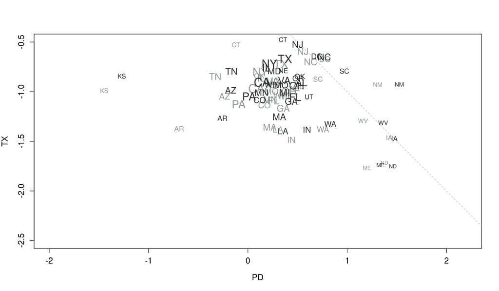

## Estimate of the YOUNG and OLD log Hazards

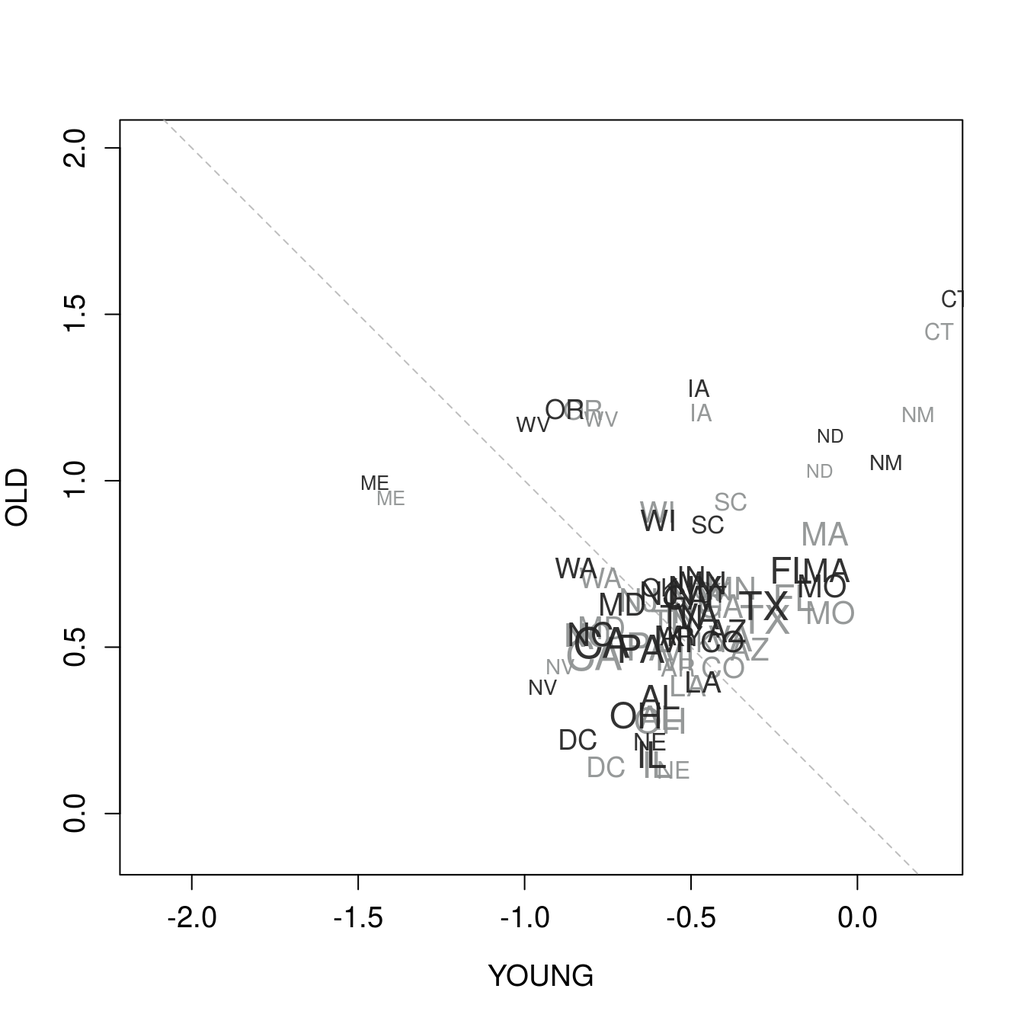

## Compare SEs using Conditional vs PLAC

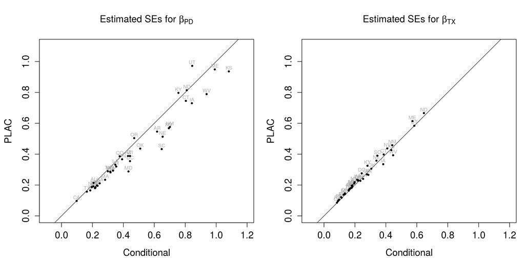

## Compare Ratio of Variances using Conditional vs PLAC

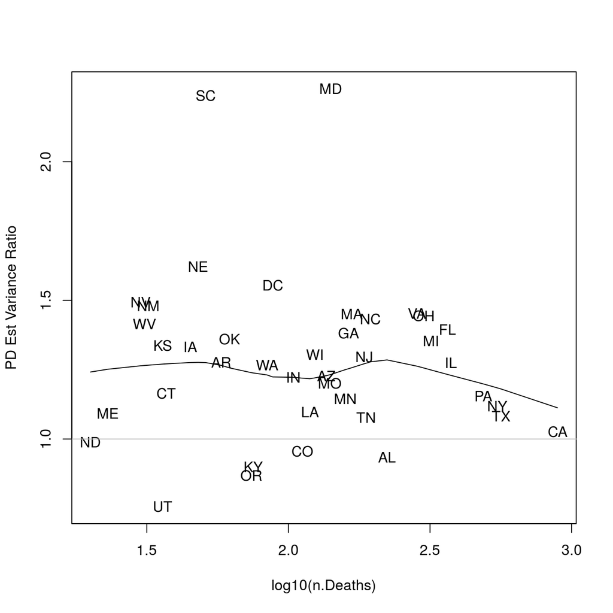

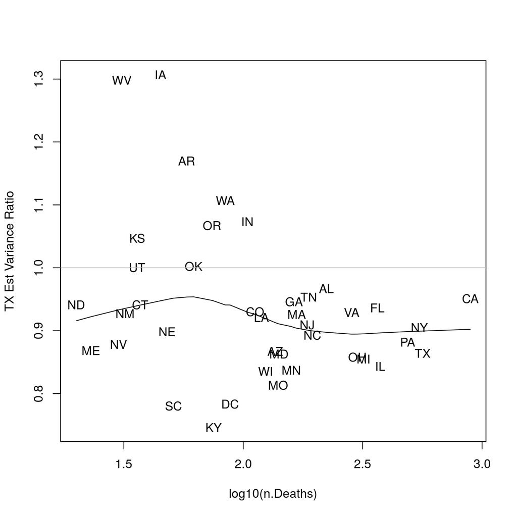

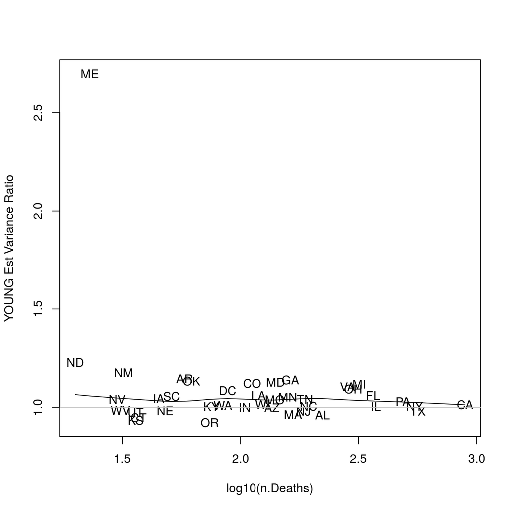

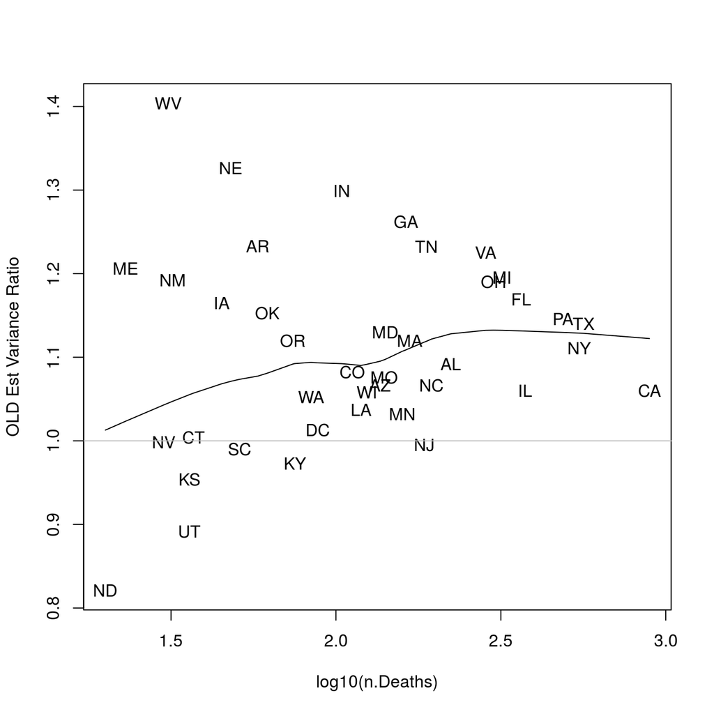

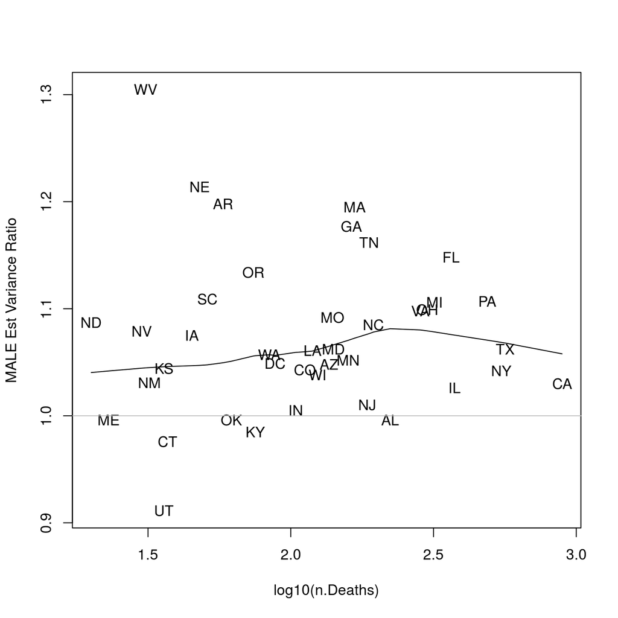

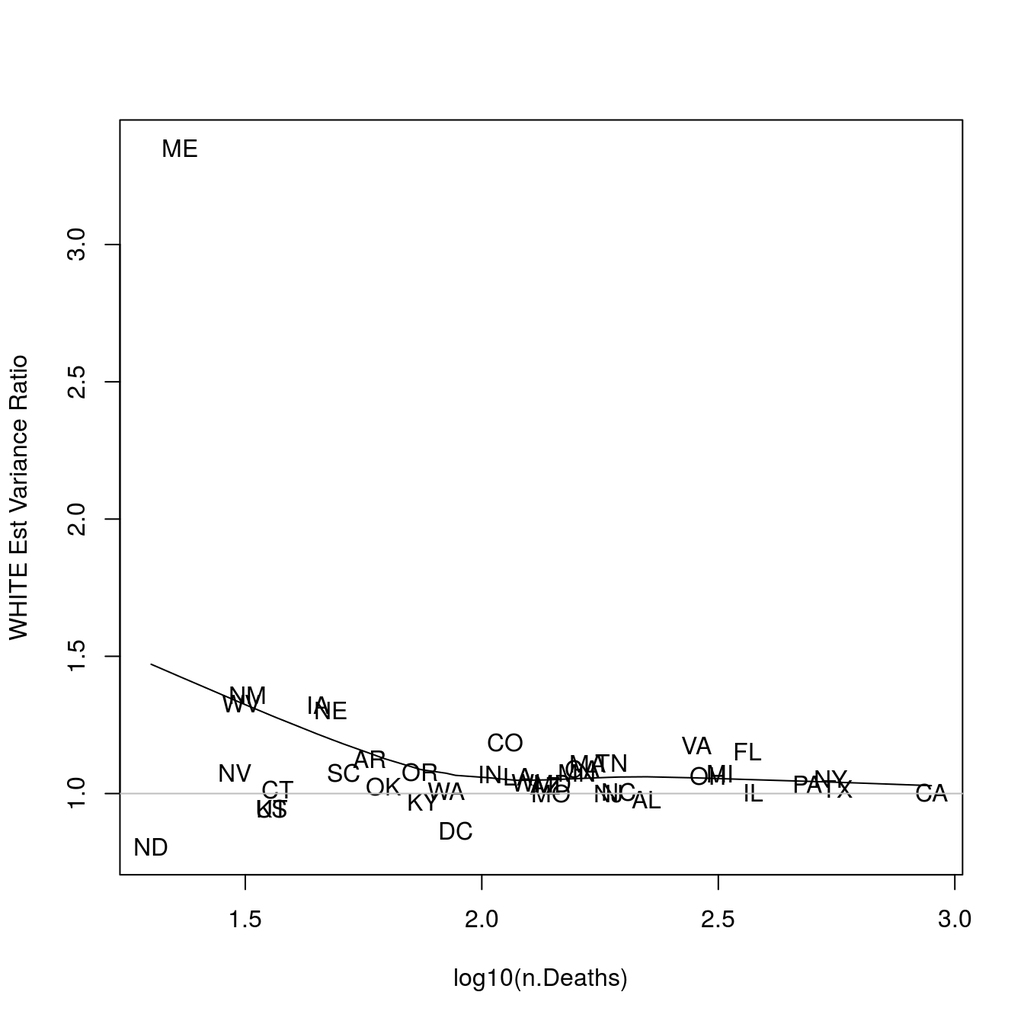

## Christmas Trees

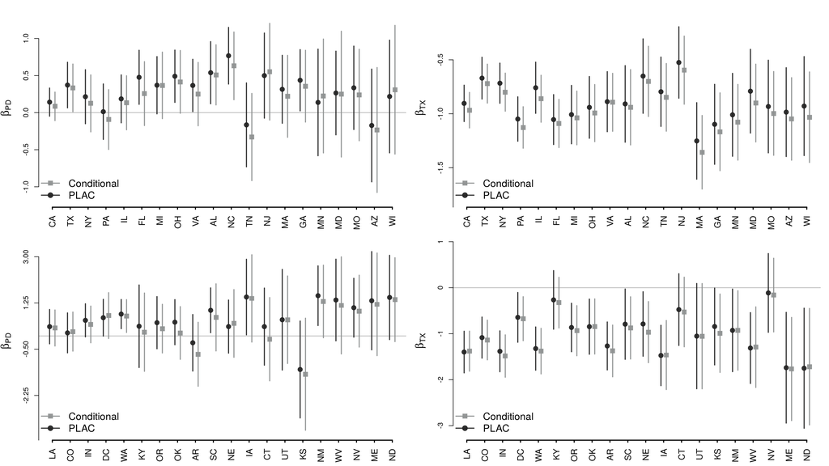

## Maps

Maps are made with a color gradient showing the magnitudes of the hazards ratios for PD and TX.

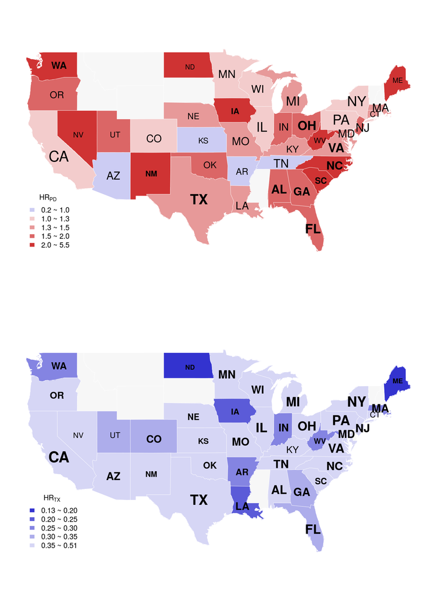

## Selected States

```
##
##
##         LHR      HR      SE      Z        P       LHR      HR      SE      Z        P       RE
## ------  -------  ------  ------  -------  ------  -------  ------  ------  -------  ------  ------
## YOUNG   -0.192   0.825   0.141   -1.359   0.174   -0.201   0.818   0.137   -1.467   0.142   1.060
## OLD     0.649    1.913   0.118   5.491    0.000   0.732    2.078   0.109   6.696    0.000   1.169
## WHITE   0.341    1.406   0.108   3.151    0.002   0.443    1.557   0.101   4.393    0.000   1.154
## MALE    0.273    1.314   0.108   2.524    0.012   0.269    1.308   0.101   2.662    0.008   1.148
## PD      0.257    1.294   0.220   1.169    0.242   0.477    1.612   0.186   2.562    0.010   1.395
## TX      -1.090   0.336   0.114   -9.564   0.000   -1.054   0.349   0.118   -8.938   0.000   0.936
## FL 1040 364 65
##
##
##         LHR      HR      SE      Z        P       LHR      HR      SE      Z        P       RE
## ------  -------  ------  ------  -------  ------  -------  ------  ------  -------  ------  ------
## YOUNG   -0.410   0.664   0.205   -2.003   0.045   -0.517   0.596   0.192   -2.694   0.007   1.138
## OLD     0.623    1.865   0.192   3.247    0.001   0.649    1.914   0.171   3.802    0.000   1.262
## WHITE   0.554    1.740   0.174   3.175    0.001   0.615    1.850   0.167   3.678    0.000   1.089
## MALE    -0.009   0.992   0.157   -0.054   0.957   -0.007   0.993   0.145   -0.046   0.963   1.177
## PD      0.357    1.429   0.247   1.444    0.149   0.437    1.548   0.211   2.075    0.038   1.381
## TX      -1.167   0.311   0.184   -6.356   0.000   -1.098   0.333   0.189   -5.820   0.000   0.946
## GA 483 163 66.3
##
##
##         LHR      HR      SE      Z        P       LHR      HR      SE      Z        P       RE
## ------  -------  ------  ------  -------  ------  -------  ------  ------  -------  ------  ------
## YOUNG   -0.471   0.625   0.459   -1.027   0.305   -0.478   0.620   0.449   -1.064   0.287   1.043
## OLD     1.204    3.334   0.339   3.554    0.000   1.277    3.586   0.314   4.069    0.000   1.165
## WHITE   0.746    2.108   0.373   2.000    0.046   0.850    2.341   0.324   2.622    0.009   1.323
## MALE    0.775    2.172   0.407   1.905    0.057   0.808    2.244   0.393   2.059    0.039   1.075
## PD      1.423    4.151   0.843   1.688    0.091   1.475    4.372   0.730   2.020    0.043   1.333
## TX      -1.464   0.231   0.383   -3.820   0.000   -1.474   0.229   0.335   -4.395   0.000   1.307
## IA 119 45 62.2
##
##
##         LHR      HR      SE      Z        P       LHR      HR      SE      Z        P       RE
## ------  -------  ------  ------  -------  ------  -------  ------  ------  -------  ------  ------
## YOUNG   -1.185   0.306   0.531   -2.230   0.026   -1.208   0.299   0.550   -2.196   0.028   0.934
## OLD     -0.260   0.771   0.397   -0.654   0.513   -0.297   0.743   0.407   -0.731   0.465   0.954
## WHITE   -0.123   0.884   0.450   -0.273   0.785   -0.074   0.928   0.463   -0.160   0.873   0.944
```

[output cut: 33 more lines]

```
## MALE    0.142    1.153   0.229   0.620    0.535   0.133    1.142   0.223   0.597    0.550   1.057
## PD      0.755    2.127   0.317   2.381    0.017   0.829    2.290   0.282   2.942    0.003   1.266
## TX      -1.379   0.252   0.253   -5.459   0.000   -1.324   0.266   0.240   -5.512   0.000   1.107
## WA 278 84 69.8
##
##
##         LHR      HR      SE      Z        P       LHR      HR      SE      Z        P       RE
## ------  -------  ------  ------  -------  ------  -------  ------  ------  -------  ------  ------
## YOUNG   -0.771   0.463   0.505   -1.527   0.127   -0.973   0.378   0.509   -1.914   0.056   0.984
## OLD     1.186    3.273   0.471   2.520    0.012   1.170    3.222   0.397   2.946    0.003   1.404
## WHITE   0.428    1.535   0.544   0.788    0.431   0.488    1.629   0.472   1.035    0.301   1.329
## MALE    0.356    1.427   0.388   0.917    0.359   0.343    1.409   0.340   1.010    0.313   1.305
## PD      1.158    3.184   0.938   1.234    0.217   1.362    3.903   0.789   1.726    0.084   1.415
## TX      -1.293   0.275   0.447   -2.890   0.004   -1.312   0.269   0.393   -3.343   0.001   1.298
## WV 62 31 50
```